# Example analysis

This notebook provides example code and suggestions for analyzing microbiome sequence data. You can perform similar analysis in Python using the QIIME Artifact API, but I am much more comfortable and familiar with R for any kind of data analysis and plotting. This is just a personal preference, as both programming languages and external packages can perform the same tasks. I use R because I find data manipulation with the dplyr package and plotting with the ggplot2 package to be much more intuitive than doing the same thing in Python.

# Set up packages

```r
# required
library(qiime2R)
library(phyloseq)
library(tidyverse)

# optional
library(MetBrewer) # fun color palettes
```

# Read in data

I read in the QIIME artifacts as a phyloseq object. Phyloseq is an R package that has many convenient functions built in for manipulating and analyzing microbiome data. We will use the qiime2R package to import the QIIME data directly into a phyloseq object.

```r
ps <- qiime2R::qza_to_phyloseq(
  features="./data/table_dada2.qza",
  tree="./data/rooted_tree.qza",
  taxonomy="./data/taxonomy.qza",
  metadata = "./resources/metadata.txt"
)
```

# Basic filtering and parsing

I will do a bit of manipulation using phyloseq functions, then we will use the suite of tidyverse packages to do more data manipulation. Let’s start with getting relative abundance data.

```r
# remove Mitochondria and Chloroplasts
ps_filt <- phyloseq::subset_taxa(ps, ! Family %in% c("Mitochondria", "Chloroplast"))

# remove unclassified sequences
ps_filt <- phyloseq::subset_taxa(ps, Kingdom != "Unassigned")

# relative abundance
ps_rel <- phyloseq::transform_sample_counts(ps_filt, function(x) x*100/sum(x))
```

```r
taxonomy <- as.data.frame(as.matrix(ps_rel@tax_table)) %>%
  rownames_to_column(var = "seq") # change the ASV ID to a column, not a row name

head(taxonomy)
```

|  | seq | Kingdom | Phylum | Class | Order | Family | Genus | Species |
| --- | --- | --- | --- | --- | --- | --- | --- | --- |
| 1 | 5114521d8980ba37112bdc615b072408 | Bacteria | NA | NA | NA | NA | NA | NA |
| 2 | 8233997f6185ea78fc5264d391cc83cc | Bacteria | NA | NA | NA | NA | NA | NA |
| 3 | ed34436d694dd44ac4be3d7e3bddf3dd | Bacteria | NA | NA | NA | NA | NA | NA |
| 4 | 10e84e3135cbe34afded24e99b311170 | Bacteria | NA | NA | NA | NA | NA | NA |
| 5 | d03b505bf687ce206e82a2d862887a0b | Bacteria | NA | NA | NA | NA | NA | NA |
| 6 | 65aa61ddfa813a524b53ea42110721a6 | Bacteria | NA | NA | NA | NA | NA | NA |

```r
metadata <- as.data.frame(as.matrix(ps_rel@sam_data)) %>%
  rownames_to_column(var = "sample")

head(metadata)
```

|  | sample | date | location | carbon | timepoint | air_temp |
| --- | --- | --- | --- | --- | --- | --- |
| 1 | C1 | 9/7/21 | control | y | 183 | 75 |
| 2 | C10 | 11/8/21 | control | y | 245 | 56 |
| 3 | C15 | 12/13/21 | control | y | 280 | 42 |
| 4 | C16 | 1/12/22 | control | y | 310 | 37 |
| 5 | C5 | 10/4/21 | control | y | 210 | 68 |
| 6 | T22 | 9/7/21 | test | y | 183 | 75 |

```r
table_rel <- as.data.frame(as.matrix(ps_rel@otu_table)) %>%
  rownames_to_column(var = "seq")

head(table_rel)
```

|  | seq | C1 | C10 | C15 | C16 | C5 | T22 | T26 | T31 | T35 | T36 |
| --- | --- | --- | --- | --- | --- | --- | --- | --- | --- | --- | --- |
| 1 | 5114521d8980ba37112bdc615b072408 | 0 | 0 | 0.00000000 | 0 | 0.00000000 | 0 | 0.00000000 | 0.00000000 | 0 | 0 |
| 2 | 8233997f6185ea78fc5264d391cc83cc | 0 | 0 | 0.00000000 | 0 | 0.00000000 | 0 | 0.01486989 | 0.24342513 | 0 | 0 |
| 3 | ed34436d694dd44ac4be3d7e3bddf3dd | 0 | 0 | 0.00000000 | 0 | 0.00000000 | 0 | 0.00000000 | 0.07159563 | 0 | 0 |
| 4 | 10e84e3135cbe34afded24e99b311170 | 0 | 0 | 0.01021138 | 0 | 0.00000000 | 0 | 0.00000000 | 0.02386521 | 0 | 0 |
| 5 | d03b505bf687ce206e82a2d862887a0b | 0 | 0 | 0.00000000 | 0 | 0.00000000 | 0 | 0.00000000 | 0.00000000 | 0 | 0 |
| 6 | 65aa61ddfa813a524b53ea42110721a6 | 0 | 0 | 0.04084550 | 0 | 0.02100399 | 0 | 0.02478315 | 0.12887213 | 0 | 0 |

This chunk manipulates the relative abundance table and combines it with the taxonomy table. We used the pivot_longer function to make this into a “long” dataframe, which is the desired format for using ggplot2. Read a bit more about long format here: http://eriqande.github.io/rep-res-web/lectures/ggplot_2_reshape_facets_stats.html. The long format will seem very chaotic, but I promise it will be extremely useful for plotting and data analysis tasks going forward.

```r
table_rel <- table_rel %>%
  pivot_longer(cols = !seq, names_to = "sample", values_to = "rel_ab") %>% # make a "long" dataframe
  left_join(taxonomy, join_by(seq)) %>% # join taxonomy by the sequence ID
  left_join(metadata, join_by(sample)) # join metadata by the sample ID


head(table_rel)
```

| seq | sample | rel_ab | Kingdom | Phylum | Class | Order | Family | Genus | Species | date | location | carbon | timepoint | air_temp |
| --- | --- | --- | --- | --- | --- | --- | --- | --- | --- | --- | --- | --- | --- | --- |
| 5114521d8980ba37112bdc615b072408 | C1 | 0 | Bacteria | NA | NA | NA | NA | NA | NA | 9/7/21 | control | y | 183 | 75 |
| 5114521d8980ba37112bdc615b072408 | C10 | 0 | Bacteria | NA | NA | NA | NA | NA | NA | 11/8/21 | control | y | 245 | 56 |
| 5114521d8980ba37112bdc615b072408 | C15 | 0 | Bacteria | NA | NA | NA | NA | NA | NA | 12/13/21 | control | y | 280 | 42 |
| 5114521d8980ba37112bdc615b072408 | C16 | 0 | Bacteria | NA | NA | NA | NA | NA | NA | 1/12/22 | control | y | 310 | 37 |
| 5114521d8980ba37112bdc615b072408 | C5 | 0 | Bacteria | NA | NA | NA | NA | NA | NA | 10/4/21 | control | y | 210 | 68 |
| 5114521d8980ba37112bdc615b072408 | T22 | 0 | Bacteria | NA | NA | NA | NA | NA | NA | 9/7/21 | test | y | 183 | 75 |

# Subsetting and plotting

We can use a variety of filtering functions from dplyr to manipulate data for more concise plots. For example, we could select specific bacteria to look for, or group all members of the same family or genus together. Let’s do a simple example - we will plot the abundance of the genus Zoogleoa from each sampling location. First, let’s see what the data looks like when we filter it to our specifications.

```r
table_rel %>% # perform some functions on table_rel
  group_by(Genus, timepoint, location) %>% # group at the genus level, we will use this to sum up everything that has the same genus (ignore species)
  summarise(sum_ab = sum(rel_ab)) %>% # sum up the relative abundance of each unique Genus at each unique combination of date and location
  filter(Genus == "Zoogloea")
```

| Genus | timepoint | location | sum_ab |
| --- | --- | --- | --- |
| Zoogloea | 183 | control | 5.659472 |
| Zoogloea | 183 | test | 2.563636 |
| Zoogloea | 210 | control | 3.250368 |
| Zoogloea | 210 | test | 1.615861 |
| Zoogloea | 245 | control | 2.864277 |
| Zoogloea | 245 | test | 1.283948 |
| Zoogloea | 280 | control | 8.209946 |
| Zoogloea | 280 | test | 6.052942 |
| Zoogloea | 310 | control | 7.029199 |
| Zoogloea | 310 | test | 7.645937 |

We can save that table as a new R data frame, or we can pipe that data directly into a ggplot2 command. Notice that the timepoint column is the “character” class rather than a numeric class like a “double” Let’s add a modification so the timepoint column is correctly classified.

```r
table_rel %>% # perform some functions on table_rel
  group_by(Genus, timepoint, location) %>%
  summarise(sum_ab = sum(rel_ab)) %>%
  filter(Genus == "Zoogloea") %>%
  mutate(timepoint = as.numeric(timepoint)) # save timepoint to a numeric class
```

| Genus | timepoint | location | sum_ab |
| --- | --- | --- | --- |
| Zoogloea | 183 | control | 5.659472 |
| Zoogloea | 183 | test | 2.563636 |
| Zoogloea | 210 | control | 3.250368 |
| Zoogloea | 210 | test | 1.615861 |
| Zoogloea | 245 | control | 2.864277 |
| Zoogloea | 245 | test | 1.283948 |
| Zoogloea | 280 | control | 8.209946 |
| Zoogloea | 280 | test | 6.052942 |
| Zoogloea | 310 | control | 7.029199 |
| Zoogloea | 310 | test | 7.645937 |

Next, we can make a simple plot showing the Zoogloea abundance over time. Let’s pipe the data directly into the ggplot command.

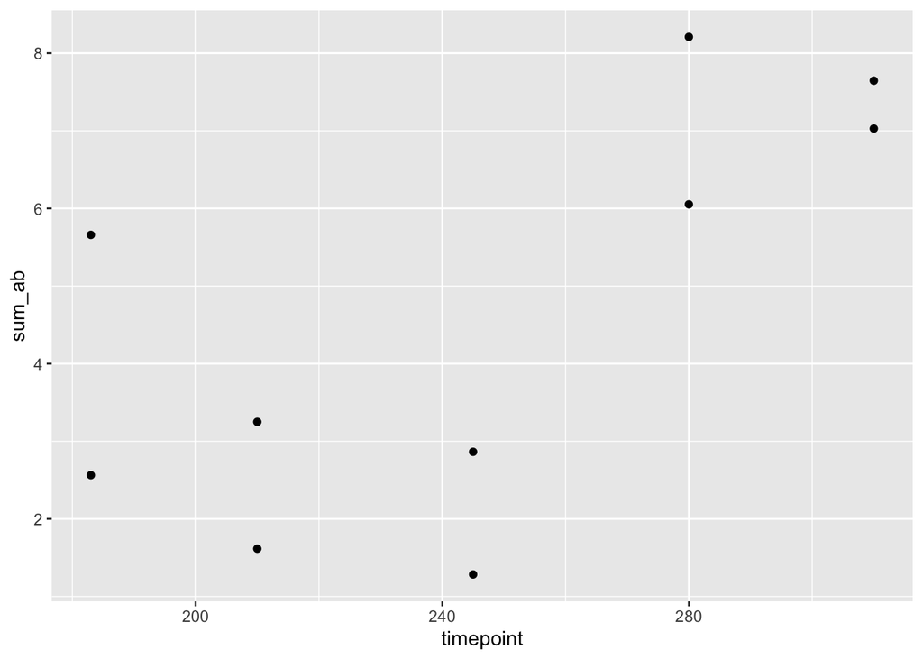

```r
table_rel %>% # perform some functions on table_rel
  group_by(Genus, timepoint, location) %>%
  summarise(sum_ab = sum(rel_ab)) %>%
  filter(Genus == "Zoogloea") %>%
  mutate(timepoint = as.numeric(timepoint)) %>% # pipe the data into the next line
  ggplot(., aes(x = timepoint, y = sum_ab)) + # the period denotes that we want to use the data we piped in
  geom_point()
```

This plot is okay, but we want to show the Zoogloea abundance from each sampling location, not all together. This is where the long data format comes in handy - we can easily tell ggplot2 that we want to change the aesthetics of the plot based on a column variable, in this case location.

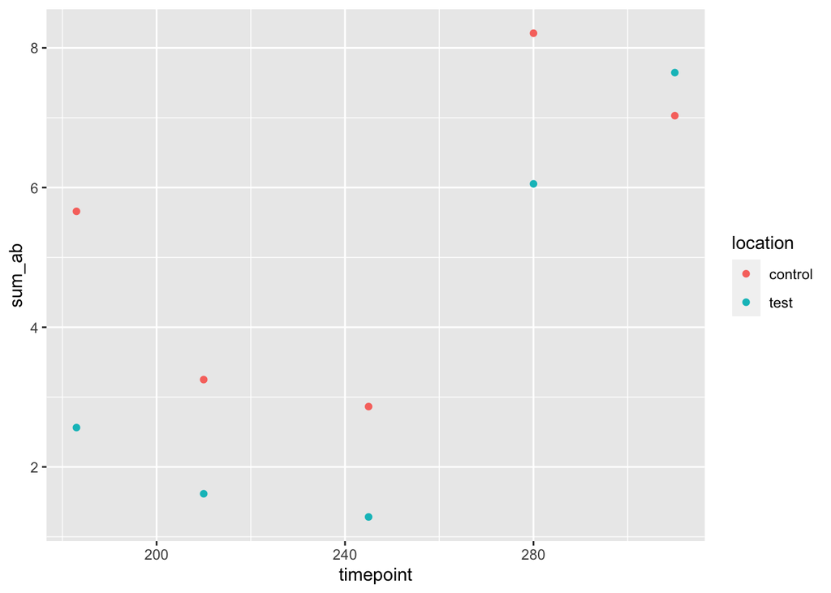

```r
table_rel %>% # perform some functions on table_rel
  group_by(Genus, timepoint, location) %>%
  summarise(sum_ab = sum(rel_ab)) %>%
  filter(Genus == "Zoogloea") %>%
  mutate(timepoint = as.numeric(timepoint)) %>% # pipe the data into the next line
  ggplot(., aes(x = timepoint, y = sum_ab, color = location)) + # add color to the aesthetics
  geom_point()
```